# Homework_7

Cai McCann

2/26/2020

```r
# load library
library(ggplot2) # for graphics

# read in my file
z <- read.table("C:\\Users\\clmcs\\Desktop\\BIOL381_McCann1\\clinical_full_clean.csv",header=TRUE,sep=",", stringsAsFactors=FALSE)

# explore the data as desired (but commented out for knitting)
# str(z)
# summary(z)
# head(z)
```

### Question 1: Go back to your “thinking on paper” exercise, and decide on a pattern that you might expect in your experiment if a specific hypothesis were true.

While these retrospective clinical data lack conventional treatment groups, the goal of collection was to investigate key variables that characterize the effects of smoking at various capacities on BMI health outcomes.

The “treatment” is whether patients in the study currently smoke in any capacity (from study categories “Current Every Day Smoker”, “Light Tobacco Smoker”, “Current Some Day Smoker”). The “control” is those who have never smoked (from study categories “Passive Smoke Exposure - Never Smoker” and “Never Smoker”).

If current smoking lifestyle truly exacerbates BMI, we expect there to be statistically significant differences in BMI between the smoking and nonsmoking groups.

### Question 2: To start simply, assume that the data in each of your treatment groups follow a normal distribution. Specify the sample sizes, means, and variances for each group that would be reasonable if your hypothesis were true.

Possible parameters under a normal distribution:

*Control*

- sample size = 707
- mean = 25
- sd = 6

*Treatment*

- sample size = 175
- mean >= 28
- sd = 6

*Former Smokers*

- sample size = 355
- mean >= 28
- sd = 6

*ANOVA will be helpful for this analysis of a discrete/categorical independent variable and a continuous dependent variable.

### Question 3: Using the methods we have covered in class, write code to create a random data set that has these attributes. Organize these data into a data frame or tibble with the appropriate structure.

```r
# specify group attributes
n_group <- 3 # number of groups
n_name <- c("Nonsmoking","Smoking","Formersmoking") # name the groups, these are essentially global variables
n_size <- c(707,175,355)
n_mean <- c(25,28,28)
n_sd<- c(6,6,6)

fake_data_lab <- rep(n_name, n_size)
head(fake_data_lab)
```

```
## [1] "Nonsmoking" "Nonsmoking" "Nonsmoking" "Nonsmoking" "Nonsmoking"
## [6] "Nonsmoking"
```

```r
# organize these data into a data frame or tibble with the appropriate structure

id <- 1:(sum(n_size))
norm_val <- c(rnorm(n=n_size[1],mean=n_mean[1],sd=n_sd[1]),
             rnorm(n=n_size[2],mean=n_mean[2],sd=n_sd[2]),
             rnorm(n=n_size[3],mean=n_mean[3],sd=n_sd[3]))

my_data <- data.frame(id,fake_data_lab,norm_val)
str(my_data)
```

```
## 'data.frame':    1237 obs. of  3 variables:
##  $ id           : int  1 2 3 4 5 6 7 8 9 10 ...
##  $ fake_data_lab: chr  "Nonsmoking" "Nonsmoking" "Nonsmoking" "Nonsmoking" ...
##  $ norm_val     : num  20.6 18.9 30.2 29.1 19.8 ...
```

```r
head(my_data)
```

```
##   id fake_data_lab norm_val
## 1  1    Nonsmoking 20.58183
## 2  2    Nonsmoking 18.94421
## 3  3    Nonsmoking 30.18519
## 4  4    Nonsmoking 29.09145
## 5  5    Nonsmoking 19.80733
## 6  6    Nonsmoking 33.37911
```

### Question 4: Now write code to analyze the data (probably as an ANOVA or regression analysis, but possibly as a logistic regression or contingency table analysis. Write code to generate a useful graph of the data.

```r
# write code to analyze the data (as an ANOVA of BMI by smoking status)
m_anova <- aov(my_data$norm_val ~ my_data$fake_data_lab)
summary(m_anova)
```

```
##                         Df Sum Sq Mean Sq F value   Pr(>F)
## my_data$fake_data_lab    2   1897   948.5   28.64 6.96e-13 ***
## Residuals             1234  40870    33.1
## ---
## Signif. codes:  0 '***' 0.001 '**' 0.01 '*' 0.05 '.' 0.1 ' ' 1
```

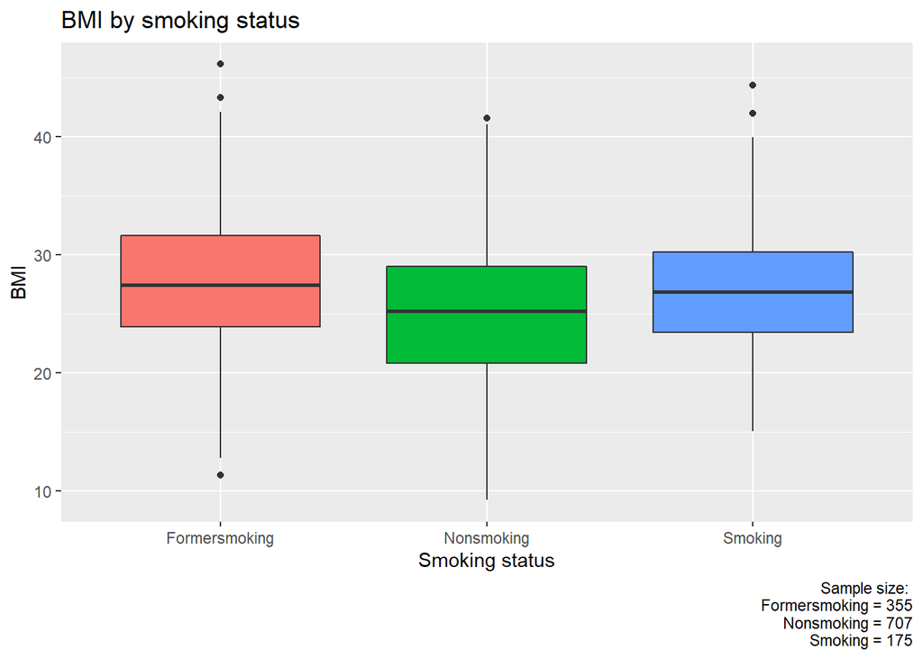

```r
# str(m_anova) # metadata, commented out for more concise knitting

# Write code to generate a useful graph of the data--box and whisker!
p_ano <- ggplot(data=my_data,
                   aes(x=fake_data_lab,
                       y=norm_val,
                       fill=fake_data_lab)) +
   geom_boxplot() +
   labs(title='BMI by smoking status',
        x='Smoking status',
        y='BMI',
        caption= 'Sample size:
                  Formersmoking = 355
                  Nonsmoking = 707
                  Smoking = 175') +
   guides(fill=FALSE) # removed legend because redundent

print(p_ano)
```

```r
ggsave(filename="HW7_anovaplot.pdf",plot=p_ano,device="pdf") #super useful export for repeatibility
```

### Question 5: Try running your analysis multiple times to get a feeling for how variable the results are with the same parameters, but different sets of random numbers.

*Code not shown for brevity but assume it is the same as previous iterations.

*Trial 1*

```
##   id fake_data_lab norm_val
## 1  1    Nonsmoking 31.23521
## 2  2    Nonsmoking 25.14399
## 3  3    Nonsmoking 27.01169
## 4  4    Nonsmoking 18.47671
## 5  5    Nonsmoking 18.34288
## 6  6    Nonsmoking 27.80978
```

```
##                         Df Sum Sq Mean Sq F value Pr(>F)
## my_data$fake_data_lab    2   3636  1817.9   51.28 <2e-16 ***
## Residuals             1234  43748    35.5
## ---
## Signif. codes:  0 '***' 0.001 '**' 0.01 '*' 0.05 '.' 0.1 ' ' 1
```

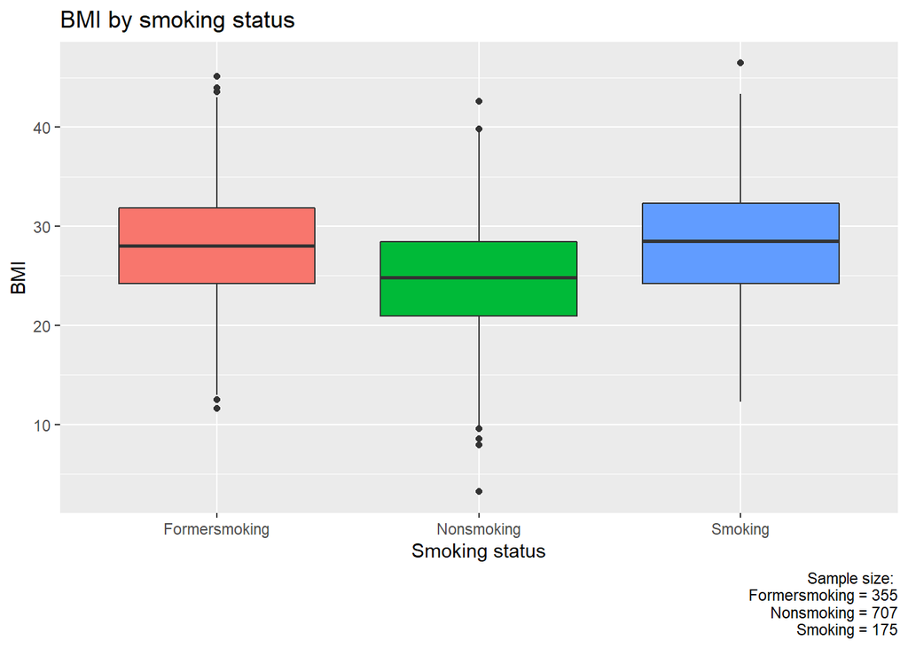

*Trial 2*

```
##   id fake_data_lab norm_val
## 1  1    Nonsmoking 24.27755
## 2  2    Nonsmoking 27.71803
## 3  3    Nonsmoking 18.08123
## 4  4    Nonsmoking 32.47320
## 5  5    Nonsmoking 24.93950
## 6  6    Nonsmoking 31.54145
```

```
##                         Df Sum Sq Mean Sq F value Pr(>F)
## my_data$fake_data_lab    2   3461  1730.5   49.55 <2e-16 ***
## Residuals             1234  43093    34.9
## ---
## Signif. codes:  0 '***' 0.001 '**' 0.01 '*' 0.05 '.' 0.1 ' ' 1
```

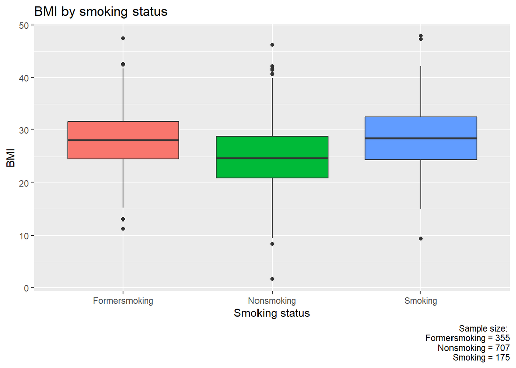

*Trial 3*

```
##   id fake_data_lab norm_val
## 1  1    Nonsmoking 24.23596
## 2  2    Nonsmoking 29.01398
## 3  3    Nonsmoking 21.40106
## 4  4    Nonsmoking 21.30395
## 5  5    Nonsmoking 27.77320
## 6  6    Nonsmoking 18.51795
```

```
##                         Df Sum Sq Mean Sq F value Pr(>F)
## my_data$fake_data_lab    2   2912  1456.1   40.99 <2e-16 ***
## Residuals             1234  43841    35.5
## ---
## Signif. codes:  0 '***' 0.001 '**' 0.01 '*' 0.05 '.' 0.1 ' ' 1
```

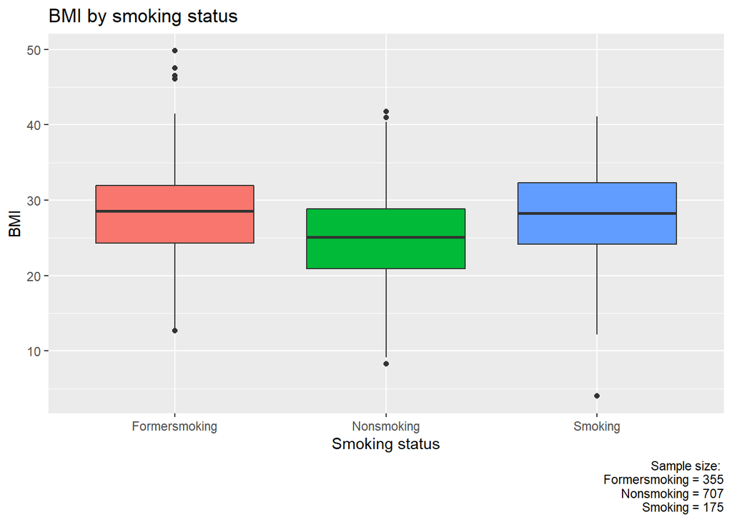

With different sets of random numbers, we still obtain similar strong p values and high F test statistics, which suggest that there is a significant difference in BMI among the different smoking groups.

### Question 6: Now begin adjusting the means of the different groups. Given the sample sizes you have chosen, how small can the differences between the groups be (the “effect size”) for you to still detect a significant pattern (p < 0.05)?

*Please note for the following trials that resulting p value and F statistic are a function of what I ran at that specific time; however, I am examining the percentage of times of running that specific set of parameters that yield significant results (most trials for 20 iterations). Therefore, significance ~1% still means that the result could be significant, and vice versa. Further work with machine learning techniques could be useful for honing on the most exact parameters to yield significance.

#### *Trial 1: significance ~1% of the time*

Means:

- Nonsmoking = 25
- Smoking = 25
- Formersmoking = 25

```r
# specify group attributes
n_group <- 3 # number of groups
n_name <- c("Nonsmoking","Smoking","Formersmoking") # name the groups, these are essentially global variables
n_size <- c(707,175,355)
n_mean <- c(25,25,25)
n_sd<- c(6,6,6)
fake_data_lab <- rep(n_name, n_size)

# organize these data into a data frame or tibble with the appropriate structure
id <- 1:(sum(n_size))
norm_val <- c(rnorm(n=n_size[1],mean=n_mean[1],sd=n_sd[1]),
             rnorm(n=n_size[2],mean=n_mean[2],sd=n_sd[2]),
             rnorm(n=n_size[3],mean=n_mean[3],sd=n_sd[3]))

my_data <- data.frame(id,fake_data_lab,norm_val)
head(my_data)
```

```
##   id fake_data_lab norm_val
## 1  1    Nonsmoking 40.95905
## 2  2    Nonsmoking 17.98035
## 3  3    Nonsmoking 21.62410
## 4  4    Nonsmoking 30.36395
## 5  5    Nonsmoking 26.68386
## 6  6    Nonsmoking 25.66160
```

```r
# write code to analyze the data (as an ANOVA of BMI by smoking status)
m_anova <- aov(my_data$norm_val ~ my_data$fake_data_lab)
summary(m_anova)
```

```
##                         Df Sum Sq Mean Sq F value Pr(>F)
## my_data$fake_data_lab    2     18    8.98   0.241  0.786
## Residuals             1234  46052   37.32
```

#### *Trial 2: significance ~50% of the time*

Means:

- Nonsmoking = 25
- Smoking = 25.88
- Formersmoking = 25.88

```r
# specify group attributes
n_group <- 3 # number of groups
n_name <- c("Nonsmoking","Smoking","Formersmoking") # name the groups, these are essentially global variables
n_size <- c(707,175,355)
n_mean <- c(25,25.88,25.88)
n_sd<- c(6,6,6)
fake_data_lab <- rep(n_name, n_size)

# organize these data into a data frame or tibble with the appropriate structure
id <- 1:(sum(n_size))
norm_val <- c(rnorm(n=n_size[1],mean=n_mean[1],sd=n_sd[1]),
             rnorm(n=n_size[2],mean=n_mean[2],sd=n_sd[2]),
             rnorm(n=n_size[3],mean=n_mean[3],sd=n_sd[3]))

my_data <- data.frame(id,fake_data_lab,norm_val)
head(my_data)
```

```
##   id fake_data_lab norm_val
## 1  1    Nonsmoking 19.25457
## 2  2    Nonsmoking 15.50021
## 3  3    Nonsmoking 25.95745
## 4  4    Nonsmoking 23.06931
## 5  5    Nonsmoking 17.53260
## 6  6    Nonsmoking 14.10743
```

```r
# write code to analyze the data (as an ANOVA of BMI by smoking status)
m_anova <- aov(my_data$norm_val ~ my_data$fake_data_lab)
summary(m_anova)
```

```
##                         Df Sum Sq Mean Sq F value Pr(>F)
## my_data$fake_data_lab    2    162   80.79   2.418 0.0895 .
## Residuals             1234  41233   33.41
## ---
## Signif. codes:  0 '***' 0.001 '**' 0.01 '*' 0.05 '.' 0.1 ' ' 1
```

#### *Trial 3: significance ~100% of the time*

Means:

- Nonsmoking = 25
- Smoking = 26.5
- Formersmoking = 26.5

```r
# specify group attributes
n_group <- 3 # number of groups
n_name <- c("Nonsmoking","Smoking","Formersmoking") # name the groups, these are essentially global variables
n_size <- c(707,175,355)
n_mean <- c(25,26.5,26.5)
n_sd<- c(6,6,6)
fake_data_lab <- rep(n_name, n_size)

# organize these data into a data frame or tibble with the appropriate structure
id <- 1:(sum(n_size))
norm_val <- c(rnorm(n=n_size[1],mean=n_mean[1],sd=n_sd[1]),
             rnorm(n=n_size[2],mean=n_mean[2],sd=n_sd[2]),
             rnorm(n=n_size[3],mean=n_mean[3],sd=n_sd[3]))

my_data <- data.frame(id,fake_data_lab,norm_val)
head(my_data)
```

```
##   id fake_data_lab norm_val
## 1  1    Nonsmoking 27.00695
## 2  2    Nonsmoking 34.59870
## 3  3    Nonsmoking 12.28974
## 4  4    Nonsmoking 26.51611
## 5  5    Nonsmoking 23.24415
## 6  6    Nonsmoking 28.93406
```

```r
# write code to analyze the data (as an ANOVA of BMI by smoking status)
m_anova <- aov(my_data$norm_val ~ my_data$fake_data_lab)
summary(m_anova)
```

```
##                         Df Sum Sq Mean Sq F value   Pr(>F)
## my_data$fake_data_lab    2    518  259.14   7.059 0.000895 ***
## Residuals             1234  45302   36.71
## ---
## Signif. codes:  0 '***' 0.001 '**' 0.01 '*' 0.05 '.' 0.1 ' ' 1
```

Roughly estimating and assuming sample size is constant, the minimum difference in means can be ~1.5 in order to detect a significant pattern. Anything smaller results insignificance and inconsistent p values, e.g. Trial 1 rarely resulted in significant p values (0/20 iterations), while Trial 2 resulted in significant p values ~50% of the time (11/20 iterations).

### Question 7: Alternatively, for the effect sizes you originally hypothesized, what is the minimum sample size you would need in order to detect a statistically significant effect? Again, run the model a few times with the same parameter set to get a feeling for the effect of random variation in the data.

*Please note for the following trials that resulting p value and F statistic are a function of what I ran at that specific time; however, I am examining the percentage of times of running that specific set of parameters that yield significant results (most trials for 20 iterations). Therefore, significance ~1% still means that the result could be significant, and vice versa. Further work with machine learning techniques could be useful for honing on the most exact parameters to yield significance.

#### *Trial 1: significance ~1% of the time*

Sample sizes:

- Nonsmoking = 1
- Smoking = 3
- Formersmoking = 3

```r
# specify group attributes
n_group <- 3 # number of groups
n_name <- c("Nonsmoking","Smoking","Formersmoking") # name the groups, these are essentially global variables
n_size <- c(1,3,3) # original totaled 1237
n_mean <- c(25,28,28)
n_sd<- c(6,6,6)
fake_data_lab <- rep(n_name, n_size)

# organize these data into a data frame or tibble with the appropriate structure
id <- 1:(sum(n_size))
norm_val <- c(rnorm(n=n_size[1],mean=n_mean[1],sd=n_sd[1]),
             rnorm(n=n_size[2],mean=n_mean[2],sd=n_sd[2]),
             rnorm(n=n_size[3],mean=n_mean[3],sd=n_sd[3]))

my_data <- data.frame(id,fake_data_lab,norm_val) # thanks to Sophie for explaining associated processes!
head(my_data)
```

```
##   id fake_data_lab norm_val
## 1  1    Nonsmoking 19.90048
## 2  2       Smoking 26.80295
## 3  3       Smoking 20.80025
## 4  4       Smoking 27.56960
## 5  5 Formersmoking 27.38241
## 6  6 Formersmoking 32.12574
```

```r
# write code to analyze the data (as an ANOVA of BMI by smoking status)
m_anova <- aov(my_data$norm_val ~ my_data$fake_data_lab)
summary(m_anova)
```

```
##                       Df Sum Sq Mean Sq F value Pr(>F)
## my_data$fake_data_lab  2  91.34   45.67   4.562 0.0929 .
## Residuals              4  40.04   10.01
## ---
## Signif. codes:  0 '***' 0.001 '**' 0.01 '*' 0.05 '.' 0.1 ' ' 1
```

#### *Trial 2: significance ~50% of the time*

Sample sizes:

- Nonsmoking = 20
- Smoking = 22
- Formersmoking = 22

```r
# specify group attributes
n_group <- 3 # number of groups
n_name <- c("Nonsmoking","Smoking","Formersmoking") # name the groups, these are essentially global variables
n_size <- c(20,22,22)
n_mean <- c(25,28,28)
n_sd<- c(6,6,6)
fake_data_lab <- rep(n_name, n_size)

# organize these data into a data frame or tibble with the appropriate structure
id <- 1:(sum(n_size))
norm_val <- c(rnorm(n=n_size[1],mean=n_mean[1],sd=n_sd[1]),
             rnorm(n=n_size[2],mean=n_mean[2],sd=n_sd[2]),
             rnorm(n=n_size[3],mean=n_mean[3],sd=n_sd[3]))

my_data <- data.frame(id,fake_data_lab,norm_val)
head(my_data)
```

```
##   id fake_data_lab norm_val
## 1  1    Nonsmoking 21.58739
## 2  2    Nonsmoking 24.14020
## 3  3    Nonsmoking 20.98591
## 4  4    Nonsmoking 19.80705
## 5  5    Nonsmoking 19.29658
## 6  6    Nonsmoking 25.92340
```

```r
# write code to analyze the data (as an ANOVA of BMI by smoking status)
m_anova <- aov(my_data$norm_val ~ my_data$fake_data_lab)
summary(m_anova)
```

```
##                       Df Sum Sq Mean Sq F value Pr(>F)
## my_data$fake_data_lab  2  194.9   97.47   3.157 0.0496 *
## Residuals             61 1883.6   30.88
## ---
## Signif. codes:  0 '***' 0.001 '**' 0.01 '*' 0.05 '.' 0.1 ' ' 1
```

Sample sizes:

- Nonsmoking = 49
- Smoking = 51
- Formersmoking = 51

```r
# specify group attributes
n_group <- 3 # number of groups
n_name <- c("Nonsmoking","Smoking","Formersmoking") # name the groups, these are essentially global variables
n_size <- c(49,51,51)
n_mean <- c(25,28,28)
n_sd<- c(6,6,6)
fake_data_lab <- rep(n_name, n_size)

# organize these data into a data frame or tibble with the appropriate structure
id <- 1:(sum(n_size))
norm_val <- c(rnorm(n=n_size[1],mean=n_mean[1],sd=n_sd[1]),
             rnorm(n=n_size[2],mean=n_mean[2],sd=n_sd[2]),
             rnorm(n=n_size[3],mean=n_mean[3],sd=n_sd[3]))

my_data <- data.frame(id,fake_data_lab,norm_val)
head(my_data)
```

```
##   id fake_data_lab norm_val
## 1  1    Nonsmoking 30.49529
## 2  2    Nonsmoking 33.44520
## 3  3    Nonsmoking 24.41948
## 4  4    Nonsmoking 23.02719
## 5  5    Nonsmoking 32.80478
## 6  6    Nonsmoking 24.80438
```

```r
# write code to analyze the data (as an ANOVA of BMI by smoking status)
m_anova <- aov(my_data$norm_val ~ my_data$fake_data_lab)
summary(m_anova)
```

```
##                        Df Sum Sq Mean Sq F value Pr(>F)
## my_data$fake_data_lab   2    164   81.84   2.239   0.11
## Residuals             148   5410   36.55
```